# Harnessing Momentum: Predictive Analysis of Stock Prices Using Linear and Nonlinear Regression II

#### **Present Cumulative Return**

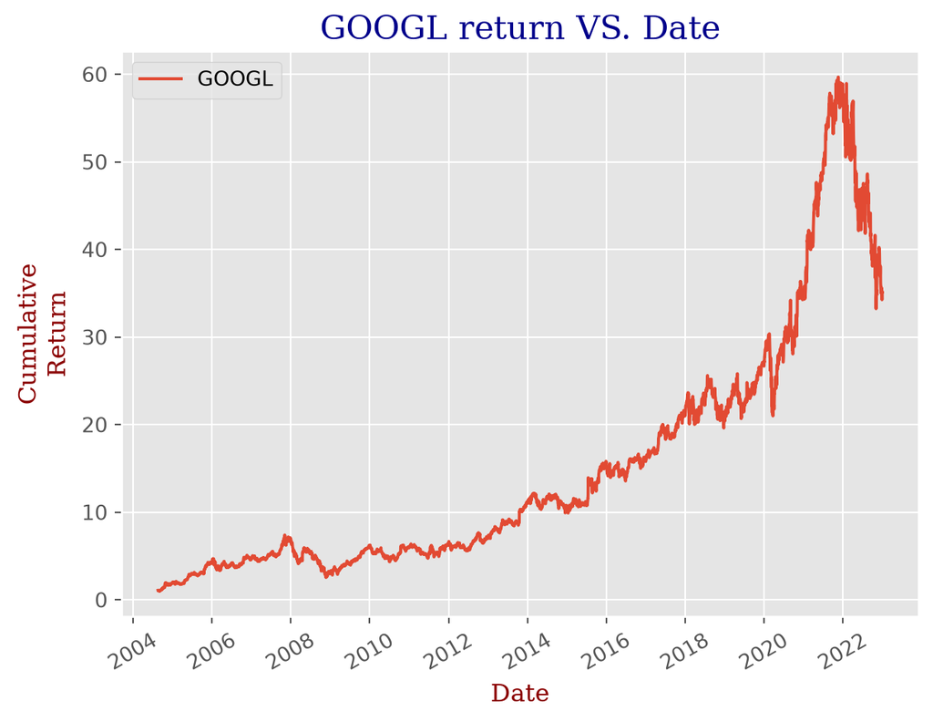

```python
return_arr = tickerDf['Close'].pct_change().dropna()
return_arr = (1+return_arr).cumprod()

fig = plt.figure()
plt.plot(return_arr.index, return_arr, label=stock)
plt.xlabel("Date", fontname='serif', color='darkred')
plt.xticks(rotation=30)
plt.ylabel("Cumulative\nReturn", fontname='serif', color='darkred')
plt.title(f"{stock} return VS. Date", fontname='serif', color='darkblue', fontsize=16)
plt.legend()
plt.plot()
```

Therefore, if we trade the stock everyday, and ignore the trading fee, this is how the principal (initial amount of investment) growth during this peroid.

#### **Retrieve Factors**

Look at the product of returns which to capture momentum effects.  
Notice that there are about 252 trading days in one year.

- **day_momentum:** This is the one-day lagged return. It measures the momentum from the previous day.
- **week_momentum:** This is the product of the past 5 days’ returns, shifted forward by one day. It measures the momentum from the past week.
- **month_momentum:** This is the product of the past 21 days’ returns, shifted forward by one day. It measures the momentum from the past month.
- **quarter_momentum:** This is the product of the past 63 days’ returns, shifted forward by one day. It measures the momentum from the past quarter.
- **year_momentum:** This is the product of the past 252 days’ returns, shifted forward by one day. It measures the momentum from the past year.
- **52_weeks_high_low_ratio:** This is the ratio of the difference between the current close price and the 52-week low to the range of the 52-week high and low. It measures how close the current price is to the 52-week high relative to the 52-week range.

52-week high:**The 52-week high momentum strategy is a trading strategy where investors go long or short on a stock when its current price is near (or far from) its 52-week high. This can be measured using the formula:**  
$\frac{P_{(i, t-1)}}{High_{(i,t-1)}}$  
where**$P_{(i, t-1)}$** is is the price of the stock at time t−1, and **$High_{(i,t-1)}$** is the highest price the stock reached in the past 52 weeks.

```python
df = pd.DataFrame()
df['return'] = tickerDf['Close'].pct_change()

# make sure not using today's data to predict today's result
df['day_momentum'] = (1 + df['return']).shift(1) - 1
df['week_momentum'] = (1 + df['return']).rolling(window=5).apply(np.prod, raw=True).shift(1) - 1
df['month_momentum'] = (1 + df['return']).rolling(window=21).apply(np.prod, raw=True).shift(1) - 1
df['quarter_momentum'] = (1 + df['return']).rolling(window=63).apply(np.prod, raw=True).shift(1) - 1
df['year_momentum'] = (1 + df['return']).rolling(window=252).apply(np.prod, raw=True).shift(1) - 1
df['52_weeks_high_low_ratio'] = (tickerDf['Close'] - tickerDf['Low'].rolling(window=252).min()) / (tickerDf['High'].rolling(window=252).max() - tickerDf['Low'].rolling(window=252).min())
df
```

| Date | return | day_momentum | week_momentum | month_momentum | quarter_momentum | year_momentum | 52_weeks_high_low_ratio |
| --- | --- | --- | --- | --- | --- | --- | --- |
| 2004-08-19 00:00:00-04:00 | NaN | NaN | NaN | NaN | NaN | NaN | NaN |
| 2004-08-20 00:00:00-04:00 | 0.079430 | NaN | NaN | NaN | NaN | NaN | NaN |
| 2004-08-23 00:00:00-04:00 | 0.010064 | 0.079430 | NaN | NaN | NaN | NaN | NaN |
| 2004-08-24 00:00:00-04:00 | -0.041408 | 0.010064 | NaN | NaN | NaN | NaN | NaN |
| 2004-08-25 00:00:00-04:00 | 0.010776 | -0.041408 | NaN | NaN | NaN | NaN | NaN |
| ... | ... | ... | ... | ... | ... | ... | ... |
| 2022-12-23 00:00:00-05:00 | 0.016750 | -0.020317 | -0.034118 | -0.095724 | -0.111201 | -0.400608 | 0.086356 |
| 2022-12-27 00:00:00-05:00 | -0.020621 | 0.016750 | -0.011411 | -0.093744 | -0.091066 | -0.392648 | 0.059379 |
| 2022-12-28 00:00:00-05:00 | -0.015677 | -0.020621 | -0.011872 | -0.103324 | -0.103692 | -0.409154 | 0.039292 |
| 2022-12-29 00:00:00-05:00 | 0.028249 | -0.015677 | -0.033700 | -0.104425 | -0.140230 | -0.413581 | 0.074920 |
| 2022-12-30 00:00:00-05:00 | -0.002487 | 0.028249 | -0.012614 | -0.070806 | -0.092076 | -0.396884 | 0.071694 |

4625 rows × 7 columns

#### Improve Factors

- **Smoothing:** Smoothing the momentum calculations with a moving average to reduce noise.
- **Risk adjustment:** Adjust the momentum calculations for risk. Divide the momentum by the standard deviation (volatility) of returns over the past year to get a risk-adjusted momentum measure.

```python
# Smoothing with a moving average
df['day_momentum_smooth'] = df['day_momentum'].rolling(window=5).mean()
df['week_momentum_smooth'] = df['week_momentum'].rolling(window=5).mean()
df['month_momentum_smooth'] = df['month_momentum'].rolling(window=5).mean()
df['quarter_momentum_smooth'] = df['quarter_momentum'].rolling(window=5).mean()
df['year_momentum_smooth'] = df['year_momentum'].rolling(window=5).mean()

# Risk adjustment
df['day_momentum_risk_adj'] = df['day_momentum'] / df['return'].rolling(window=252).std()
df['week_momentum_risk_adj'] = df['week_momentum'] / df['return'].rolling(window=252).std()
df['month_momentum_risk_adj'] = df['month_momentum'] / df['return'].rolling(window=252).std()
df['quarter_momentum_risk_adj'] = df['quarter_momentum'] / df['return'].rolling(window=252).std()
df['year_momentum_risk_adj'] = df['year_momentum'] / df['return'].rolling(window=252).std()
```

#### **Normalize or Standardize the factors**

```python
scaler = StandardScaler()
# scaler = MinMaxScaler()
df_scaled = df.dropna()
return_arr = df_scaled['return']
df_scaled = df_scaled[df_scaled.columns[1:]]
df_scaled = pd.DataFrame(scaler.fit_transform(df_scaled), columns=df.columns[1:])
df_scaled.set_index(return_arr.index, inplace=True)
df_scaled
```

| Date | day_momentum | week_momentum | month_momentum | quarter_momentum | year_momentum | 52_weeks_high_low_ratio | day_momentum_smooth | week_momentum_smooth | month_momentum_smooth | quarter_momentum_smooth | year_momentum_smooth | day_momentum_risk_adj | week_momentum_risk_adj | month_momentum_risk_adj | quarter_momentum_risk_adj | year_momentum_risk_adj |
| --- | --- | --- | --- | --- | --- | --- | --- | --- | --- | --- | --- | --- | --- | --- | --- | --- |
| 2005-08-25 00:00:00-04:00 | 0.526098 | -0.310159 | -0.747161 | 0.255181 | 4.249616 | 0.582602 | -0.297116 | -0.796104 | -1.230024 | 0.490876 | 4.181518 | 0.363544 | -0.248104 | -0.599921 | 0.038821 | 2.899085 |
| 2005-08-26 00:00:00-04:00 | -0.036394 | 0.137104 | -0.779210 | 0.303679 | 4.109359 | 0.599627 | 0.146940 | -0.653593 | -1.091965 | 0.374525 | 4.078954 | -0.039404 | 0.063938 | -0.623066 | 0.073999 | 2.797304 |
| 2005-08-29 00:00:00-04:00 | 0.145344 | 0.223297 | -0.602729 | 0.131622 | 4.266773 | 0.683374 | 0.232511 | -0.373545 | -0.903033 | 0.240201 | 4.130536 | 0.091657 | 0.125271 | -0.499924 | -0.047094 | 2.937002 |
| 2005-08-30 00:00:00-04:00 | 0.869116 | 1.206301 | -0.162035 | -0.051973 | 4.732813 | 0.663083 | 1.184219 | 0.157565 | -0.658245 | 0.193399 | 4.323529 | 0.613407 | 0.814937 | -0.186947 | -0.178942 | 3.292229 |
| 2005-08-31 00:00:00-04:00 | -0.256740 | 0.585827 | -0.372427 | -0.357315 | 4.668738 | 0.641242 | 0.581636 | 0.452240 | -0.556265 | 0.056409 | 4.407314 | -0.198509 | 0.380404 | -0.336556 | -0.398118 | 3.250344 |
| ... | ... | ... | ... | ... | ... | ... | ... | ... | ... | ... | ... | ... | ... | ... | ... | ... |
| 2022-12-23 00:00:00-05:00 | -1.115868 | -0.931891 | -1.356665 | -1.131538 | -1.917170 | -2.250567 | -0.938167 | -1.568035 | -1.299998 | -1.170135 | -1.859593 | -0.855955 | -0.714464 | -1.076112 | -0.981907 | -1.833808 |
| 2022-12-27 00:00:00-05:00 | 0.846724 | -0.372649 | -1.332556 | -0.988083 | -1.893415 | -2.352100 | -0.361857 | -1.469678 | -1.317399 | -1.122054 | -1.870063 | 0.628237 | -0.302470 | -1.057324 | -0.873380 | -1.813853 |
| 2022-12-28 00:00:00-05:00 | -1.131957 | -0.384004 | -1.449202 | -1.078040 | -1.942674 | -2.427698 | -0.373133 | -1.225992 | -1.323680 | -1.090390 | -1.889887 | -0.866906 | -0.310713 | -1.143680 | -0.940787 | -1.852810 |
| 2022-12-29 00:00:00-05:00 | -0.870187 | -0.921594 | -1.462599 | -1.338362 | -1.955887 | -2.293609 | -0.921832 | -1.011914 | -1.369715 | -1.143779 | -1.915115 | -0.667248 | -0.704125 | -1.150777 | -1.134300 | -1.860390 |
| 2022-12-30 00:00:00-05:00 | 1.455559 | -0.402278 | -1.053288 | -0.995273 | -1.906056 | -2.305748 | -0.379955 | -0.739137 | -1.389635 | -1.124418 | -1.927815 | 1.084415 | -0.323457 | -0.847154 | -0.877042 | -1.820619 |

4368 rows × 16 columns

Let’s see if the factors are correlated to our target

```python
for e in df_scaled.columns:
  factor = df_scaled[e]
  corr_coef = np.corrcoef(factor, return_arr)[0, 1]
  if np.abs(corr_coef) > 0.1:
    print(f"The correlation coefficient between {e} and target is {corr_coef:.2f}")
```

```
The correlation coefficient between 52_weeks_high_low_ratio and target is 0.13
```

Predict the return as target y for linear regression, and predict net return (0 for positive, 1 for negative) as target for logistic regression.  
Split train-test datasets to evaluate the performance of each model.

```python
X = df_scaled
y_linear = return_arr
y_logistic = normalize_and_binarize(return_arr)

X_train_linear, X_test_linear, y_train_linear, y_test_linear = train_test_split(X, y_linear, test_size=0.3, shuffle=False)
X_train_logistic, X_test_logistic, y_train_logistic, y_test_logistic = train_test_split(X, y_logistic, test_size=0.3, shuffle=False)
```

### Training the models

#### Linear model

The result is shown in a barplot, where height=1 means y_pred and y_train are in the same direction, otherwise it is -1.

```
Final loss:0.03, accuracy: 0.52
```

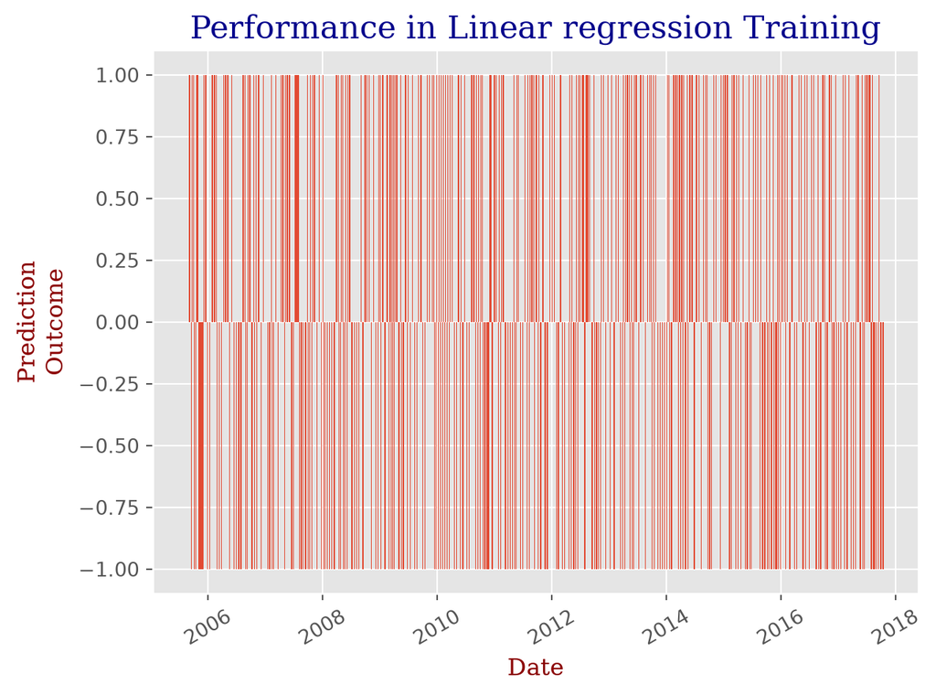

```python
# Fit the linear model
learning_rate = 0.00001
iterations = 1000

weights_linear, y_pred_linear, perform_df_linear = fit_linear(X_train_linear.values, y_train_linear.values, lr=learning_rate, num_iter=iterations)

loss = my_rmse(y_train_linear.values, y_pred_linear)
y_train_bin = normalize_and_binarize(y_train_linear.values)
y_pred_bin = normalize_and_binarize(y_pred_linear)
accu = accuracy_score(y_train_bin, y_pred_bin)
print(f"Final loss:{loss:.2f}, accuracy: {accu:.2f}")

x_axis = X_train_linear.index
y_signal = np.where(y_train_bin == y_pred_bin, 1, -1)

fig = plt.figure()
plt.bar(x_axis, y_signal)
plt.xlabel("Date", fontname='serif', color='darkred')
plt.xticks(rotation=30)
plt.ylabel("Prediction\nOutcome", fontname='serif', color='darkred')
plt.title("Performance in Linear regression Training", fontname='serif', color='darkblue', fontsize=16)
# plt.legend()
plt.show()
# Evaluate the models
# ... (depends on how you want to evaluate your models)
```

#### Logistic model

The result is shown in a barplot, where height=1 means y_pred and y_train are the same, otherwise it is -1.

```
Final loss:0.69, accuracy: 0.55
```

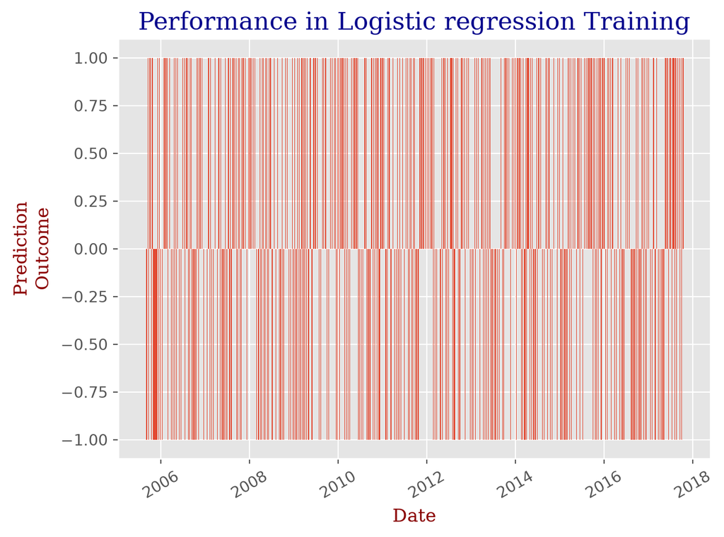

```python
# Fit the logistic model
learning_rate = 0.01
iterations = 1000

weights_logistic, h_pred_logistic, perform_df_logistic = fit_logistic(X_train_logistic.values, y_train_logistic, lr=learning_rate, num_iter=iterations)

y_pred_logistic = normalize_and_binarize(h_pred_logistic)

loss = logLoss(y_train_logistic, h_pred_logistic)
accu = accuracy_score(y_train_logistic, y_pred_logistic)
print(f"Final loss:{loss:.2f}, accuracy: {accu:.2f}")

x_axis = X_train_logistic.index
y_signal = np.where(y_train_logistic == y_pred_logistic, 1, -1)

fig = plt.figure()
plt.bar(x_axis, y_signal)
plt.xlabel("Date", fontname='serif', color='darkred')
plt.xticks(rotation=30)
plt.ylabel("Prediction\nOutcome", fontname='serif', color='darkred')
plt.title("Performance in Logistic regression Training", fontname='serif', color='darkblue', fontsize=16)
# plt.legend()
plt.show()
```

### Test the performance of Strategy based on the prediction

When we predict the return to be negative, we want to short the stock, otherwise long it. This time we are performing the prediction on the test dataset.

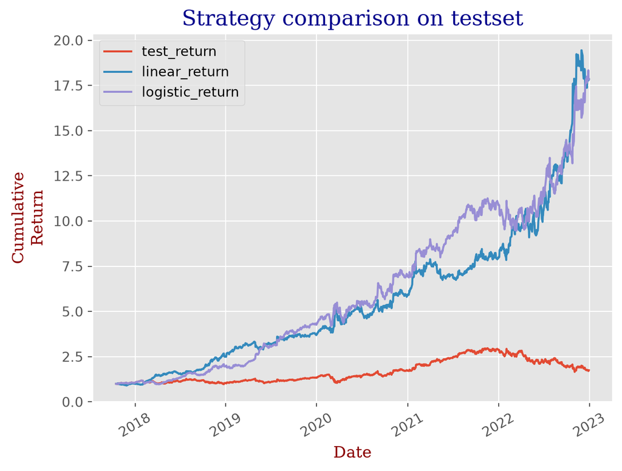

```python
y_pred_linear = linearPredict(X_test_linear, weights_linear)
y_pred_logistic = linearPredict(X_test_logistic, weights_logistic)

test_return_arr = y_test_linear

# calculate the return
y_pred_linear_return = np.where(y_pred_linear > 0, test_return_arr, -test_return_arr)
y_pred_logistic_return = np.where(y_pred_logistic > 0, test_return_arr, -test_return_arr)
x_axis = test_return_arr.index

cum_test_return = (1+test_return_arr).cumprod()
cum_linear_return = (1+y_pred_linear_return).cumprod()
cum_logistic_return = (1+y_pred_logistic_return).cumprod()


fig = plt.figure()
plt.plot(x_axis, cum_test_return, label='test_return')
plt.plot(x_axis, cum_linear_return, label='linear_return')
plt.plot(x_axis, cum_logistic_return, label='logistic_return')
plt.xlabel("Date", fontname='serif', color='darkred')
plt.xticks(rotation=30)
plt.ylabel("Cumulative\nReturn", fontname='serif', color='darkred')
plt.title("Strategy comparison on testset", fontname='serif', color='darkblue', fontsize=16)
plt.legend()
plt.show()
```

This shows the comparison among strategies, and the logistic regression predicted strategy seems shows the best performance. However, this project ignore the transaction fee, which could be very large for trading everyday. Future work could analysis the performance among strategies among differet trading frequences, e.g. make transaction every week, month, quarter, or year.

end.